# ASCILITE 2022

Erica Ho

2022-12-09

## A quick tweet analysis for ASCILITE 2022

I think ASCILITE 2022 was great! I’m curious about what others on Twitter said about the conference, but I can’t read all tweets, so I’m going to do a quick text mining and visualise the results :-)

### Data

The official hashtag for ASCILITE 2022 is #ascilite22 and I notice that there are some tweets using #ascilite2022. I searched tweets that contain either #ascilite22 or #ascilite2022 from last year (i.e., 2021) to one day after the conference (i.e., 2022-12-08 AEDT) to include all tweets, but I excluded retweets to avoid double counting things.

The raw dataset has 898 tweets but it contains some spam and irrelevant tweets. I quickly scanned through the tweets and identified some words and users that can be used to filter the tweets.

After removing spam and irrelevant tweets, the resulting dataset has 824 tweets created by 116 Twitter user accounts between 2021-11-29 12:22:42 AEDT and 2022-12-08 12:08:54 AEDT. The first tweet is about knowing in the 2021 AGM meeting that the 2022 conference would be held at the University of Sydney, while the last tweet on 2022-12-08 is about one of the talks at the conference.

As shown in the Top 10 dates below, most tweets were posted during the 3-day conference between 2022-12-05 and 2022-12-07.

|  | tweet_date | n |
| --- | --- | --- |
| 1 | 2022-12-05 | 246 |
| 2 | 2022-12-06 | 235 |
| 3 | 2022-12-07 | 195 |
| 4 | 2022-12-04 | 39 |
| 5 | 2022-05-26 | 6 |
| 6 | 2022-11-11 | 6 |
| 7 | 2022-11-24 | 6 |
| 8 | 2021-12-01 | 5 |
| 9 | 2022-12-02 | 5 |
| 10 | 2022-12-08 | 5 |

Among these 824 tweets, 18.9% were posted by the [Conference Twitter account (@asciliteconf)](https://twitter.com/asciliteconf). I excluded the tweets created by the Conference organiser to see what others said about the conference. The resulting 668 tweets are analysed and the findings are shown below.

### Word frequency analysis

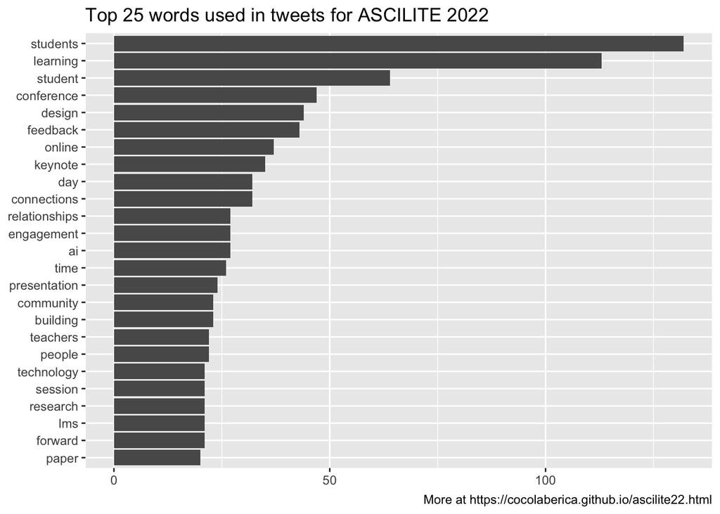

### NRC word-emotion analysis

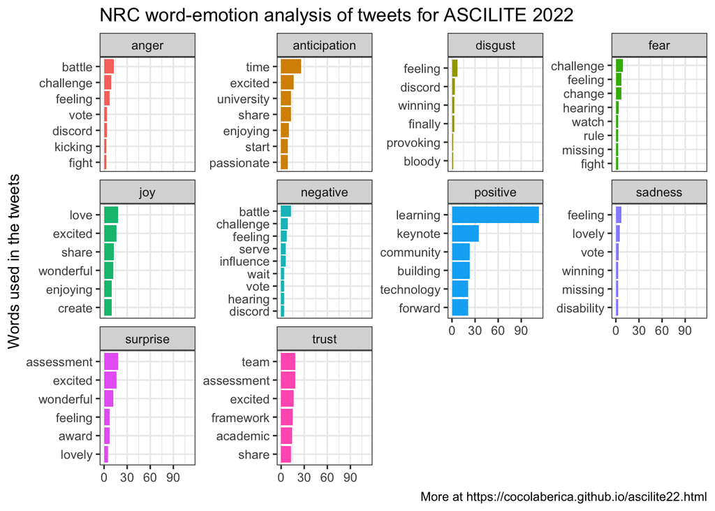

### Bing sentiment analysis

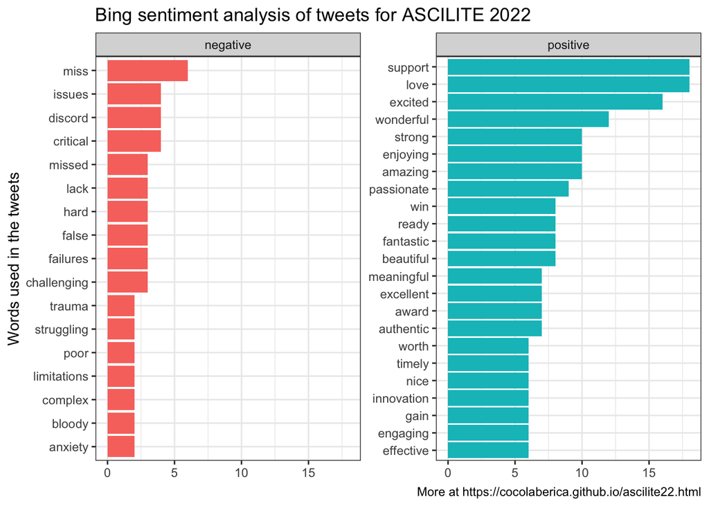

### Conclusion

This is a very brief analysis and I did it just to satisfy my curiosity. It’s nice to know that others mentioned student(s) and learning frequently and used lots of positive words in the tweets about the conference :-)

This analysis is reproducible and can be updated by using the latest dataset.

[Back to my github.io page](https://cocolaberica.github.io/)

This page is created from an R Markdown written by [@CoCoLabErica](https://www.youtube.com/@CoCoLabErica/about).